# **SPE Colombia Hackaton 2020**

**Análisis datos Agencia Nacional de Hidrocarburos - ANH**

Se describe el proceso para la lectura y procesamiento de los datos descargados de las pagina de la ANH. como anotacion se encuentra que los datos para los años 2013 y 2014 no cuentan con la columna de municipio y operadora, reemplazandose por empresa y cuenca. ademas de esto, el archivo de datos del 2014 solo tenia datos hasta el mes de octubre.

```python
from pathlib import Path
  from datetime import date , datetime
  import pandas as pd
  import numpy as np
  import matplotlib.pyplot as plt
  import seaborn as sns
  import warnings
  from scipy.optimize import curve_fit
  warnings.filterwarnings("ignore")
```

Luego de procesar estos datos se creará un df que contenga el compilado de todos los datos oficiales y blind test en el númeral

- Tabla de datos oficiales
- Tabla de datos blind

El script de lectura para ambos archivos es el mismo

```python
def lectyproc(ruta):
          #Se quiere que este código perdure en el tiempo, por tanto, se genera el código para que lea todos los excel  hasta el año actual
      today = date.today()
      #Los datos de producción se obtienen desde el año 2013
      primeraño=2013
      añoactual=today.year
      listado_años=[]
      #Un rango de fechas desde el 2013 hasta el año actual
      años = range(primeraño,añoactual+1,1)
      #Se crea una función para leer los nombres de los archivos que estan ubicados en el directorio
      def ls(ruta = Path.cwd()):
          return [arch.name for arch in Path(ruta).iterdir() if arch.is_file()]
      #Se establece la ruta dentro del directorio actual
      files=ls(ruta)
      for año in años:
          for file in files:
              añotemp = file[file.find('2'):file.find('2')+4]
              if int(año) == int(añotemp):
                  #Se leen los documentos de excel que están en el directorio especificado. Se limita las columnas de la A a la Q
                  globals()["año" + str(año)] = pd.read_excel(ruta+file,usecols='A:Q')
                  #Se eliminan las filas con valores nulos, para así quitar encabezados y totalizadores y la primera fila pasa a ser el encabezado del data frame
                  if globals()["año" + str(año)].isnull().sum().sum() != 0:
                      globals()["año" + str(año)]=globals()["año" + str(año)].dropna().reset_index(drop=True)
                      globals()["año" + str(año)]=globals()["año" + str(año)].rename(columns= globals()["año" + str(año)].iloc[0]).drop(0)

                  #Hago una lista con los nombres de las columnas del dataframe
                  globals()["año" + str(año)].columns = globals()["año" + str(año)].columns.str.upper()
                  globals()["año" + str(año)].columns = globals()["año" + str(año)].columns.str.strip()
                  globals()["column" + str(año)]=globals()["año" + str(año)].columns
                  #hallo la posición de la columna que contiene a Enero
                  for col in range(0,len( globals()["column" + str(año)])):
                      if  globals()["column" + str(año)][col].lower() == 'enero':
                          j=col
                  #Paso de formato wide a long sabiendo cual es la columna que contiene a enero, lugar desde el cual queremos hacer el pivote
                  globals()["table" + str(año)] = pd.melt(globals()["año" + str(año)], id_vars=globals()["column" + str(año)][0:j], var_name="MES", value_name="ACEITE")
                  for columna1 in globals()["column" + str(año)]:
                      if columna1 == 'EMPRESA':
                          globals()["table" + str(año)] = globals()["table" + str(año)].rename(columns={'EMPRESA': 'OPERADORA'})
                      if columna1 == 'CUENCA':
                          globals()["table" + str(año)] = globals()["table" + str(año)].rename(columns={'CUENCA': 'MUNICIPIO'})
                          globals()["table" + str(año)]['MUNICIPIO'] = 'No encontrado'
                  #Ahora convertiré el mes a número para tener datos secuenciales MM-YYYY
                  def mesnum(mes):
                      if mes.lower() == 'enero':
                          mesn = 1
                      if mes.lower() == 'febrero':
                          mesn = 2
                      if mes.lower() == 'marzo':
                          mesn = 3
                      if mes.lower() == 'abril':
                          mesn = 4
                      if mes.lower() == 'mayo':
                          mesn = 5
                      if mes.lower() == 'junio':
                          mesn = 6
                      if mes.lower() == 'julio':
                          mesn = 7
                      if mes.lower() == 'agosto':
                          mesn = 8
                      if mes.lower() == 'septiembre':
                          mesn = 9
                      if mes.lower() == 'octubre':
                          mesn = 10
                      if mes.lower() == 'noviembre':
                          mesn = 11
                      if mes.lower() == 'diciembre':
                          mesn = 12
                      return mesn
                  globals()["table" + str(año)]['MM'] = globals()["table" + str(año)]['MES'].apply(mesnum)
                  globals()["table" + str(año)]['YYYY'] = año
                  #Concateno el mes y el año
                  def concat(*args):
                      strs = [str(arg) for arg in args if not pd.isnull(arg)]
                      return '/'.join(strs) if strs else np.nan
                  np_concat = np.vectorize(concat)
                  globals()["table" + str(año)]['MM-YYYY'] = np_concat(globals()["table" + str(año)]['MM'], globals()["table" + str(año)]['YYYY'])
                  #Realizo formato de fecha
                  globals()["table" + str(año)]['FECHA'] = globals()["table" + str(año)]['MM-YYYY'].apply(lambda x: datetime.strptime(x, '%m/%Y'))
                  #Borraré columnas que creé para generar la fecha
                  globals()["table" + str(año)].drop(['MM','MM-YYYY'], axis = 'columns', inplace=True)
                  listado_años.append(globals()["table" + str(año)])
      table= pd.concat(listado_años, ignore_index=True)
      return table
```

```python
table_comp=lectyproc("Datos/Datos oficiales/")
```

```python
table_comp.to_csv('Tabla general datos oficiales.csv',index=False)
  table_comp.to_excel('Tabla general datos oficiales.xlsx',index=False)
```

```python
table_comp
```

|  | CAMPO | CONTRATO | MUNICIPIO | OPERADORA | DEPARTAMENTO | MES | ACEITE | YYYY | FECHA |
| --- | --- | --- | --- | --- | --- | --- | --- | --- | --- |
| 0 | Abanico | Abanico | No encontrado | PACIFIC STRATUS ENERGY | Tolima | ENERO | 1220.71 | 2013 | 2013-01-01 |
| 1 | Abarco | Nare | No encontrado | MANSAROVAR ENERGY COLOMBIA LTD. | Boyacá | ENERO | 5027.19 | 2013 | 2013-01-01 |
| 2 | Abedus | Cravoviejo | No encontrado | C&C ENERGÍA | Casanare | ENERO | 0 | 2013 | 2013-01-01 |
| 3 | Abejas | Estero | No encontrado | PERENCO COLOMBIA LIMITED | Casanare | ENERO | 233.806 | 2013 | 2013-01-01 |
| 4 | Acacia Este | Las Quinchas | No encontrado | PACIFIC STRATUS ENERGY | Santander | ENERO | 0 | 2013 | 2013-01-01 |
| ... | ... | ... | ... | ... | ... | ... | ... | ... | ... |
| 41395 | RÍO SALDAÑA | TOLIMA | CHAPARRAL | HOCOL S.A. | TOLIMA | AGOSTO | 1133.84 | 2020 | 2020-08-01 |
| 41396 | TOLDADO | TOLDADO | ORTEGA | HOCOL S.A. | TOLIMA | AGOSTO | 364.62 | 2020 | 2020-08-01 |
| 41397 | TOQUI TOQUI | PULI | PIEDRAS | HOCOL S.A. | TOLIMA | AGOSTO | 362.87 | 2020 | 2020-08-01 |
| 41398 | TOTARE | ARMERO | ALVARADO | HOCOL S.A. | TOLIMA | AGOSTO | 0 | 2020 | 2020-08-01 |
| 41399 | TOY | TOY | ORTEGA | HOCOL S.A. | TOLIMA | AGOSTO | 0 | 2020 | 2020-08-01 |

41400 rows × 9 columns

```python
table_comp[table_comp['YYYY']==2019]['ACEITE'].sum()
```

```
10630608.662526865
```

```python
blind_table_comp=lectyproc("Datos/Blind data/")
```

```python
blind_table_comp
```

|  | DEPARTAMENTO | MUNICIPIO | OPERADORA | CONTRATO | CAMPO | MES | ACEITE | YYYY | FECHA |
| --- | --- | --- | --- | --- | --- | --- | --- | --- | --- |
| 0 | cf33cb8a | cf33cb8a | d5580f74 | 76a16657 | 1f d2689f | ENERO | 12371.083713 | 2017 | 2017-01-01 |
| 1 | cf33cb8a | cf33cb8a | d5580f74 | 76a16657 | 9ac1420f | ENERO | 5.367156 | 2017 | 2017-01-01 |
| 2 | cf33cb8a | cf33cb8a | d5580f74 | 76a16657 | 9b395bc9 | ENERO | 120.462831 | 2017 | 2017-01-01 |
| 3 | cf33cb8a | cf33cb8a | d5580f74 | 29ded6f4 | 2f614c0b | ENERO | 23208.879752 | 2017 | 2017-01-01 |
| 4 | cf33cb8a | cf33cb8a | d5580f74 | 29ded6f4 | 043b305e | ENERO | 4386.088856 | 2017 | 2017-01-01 |
| ... | ... | ... | ... | ... | ... | ... | ... | ... | ... |
| 1459 | 0fa93c9b | 756c486f | 2fe52430 | 4b05ae15 | 373ebdec | DICIEMBRE | 1084.287554 | 2019 | 2019-12-01 |
| 1460 | 0fa93c9b | 756c486f | 2fe52430 | 4b05ae15 | e32e23a1 | DICIEMBRE | 414.497377 | 2019 | 2019-12-01 |
| 1461 | 657b6154 | a6b36c07 | ffd6d24d | 38c31ea1 | 11e586b4 | DICIEMBRE | 0.000000 | 2019 | 2019-12-01 |
| 1462 | 657b6154 | a6b36c07 | ffd6d24d | 38c31ea1 | 11e586b4 | DICIEMBRE | 408.016097 | 2019 | 2019-12-01 |
| 1463 | 657b6154 | 28b6a6a0 | ffd6d24d | 8568d01e | 8568d01e | DICIEMBRE | 166.892938 | 2019 | 2019-12-01 |

1464 rows × 9 columns

```python
blind_table_comp[blind_table_comp['YYYY']==2019]['ACEITE'].sum()
```

```
946021.7258925696
```

```python
blind_table_comp.to_csv('Tabla general datos ciegos.csv',index=False)
  blind_table_comp.to_excel('Tabla general datos ciegos.xlsx',index=False)
```

Se describe el procedimiento para las respuestas a las preguntas del reto. ademas de esto, se pasa el Data Frame a una base de datos usando Postgresql

```python
from pathlib import Path
from datetime import date , datetime
import pandas as pd
import numpy as np
import matplotlib.pyplot as plt
import seaborn as sns
import warnings
from scipy.optimize import curve_fit
from sqlalchemy import create_engine, text
warnings.filterwarnings("ignore")
```

```python
#Creando la conexión con las bases de datos postgres local Nota: postgres deja en minuscula los encabezados, por eso toca pasarlos a mayuscula de nuevo aunque esto ya se hiciera en el archivo de lectura
#engine=create_engine(f'postgresql://postgres:postgres@localhost:5432/HACKATON', max_overflow=20)
#table_comp = pd.read_sql_table('datosoficiales',engine)
#table_comp.columns = table_comp.columns.str.upper()
#Si quiere probar los resultados con postgres, descomente las tres lineas anteriores y deje como comentario la siguiente
table_comp = pd.read_csv('Datos/Tablas resumen/Tabla general datos oficiales.csv')
```

```python
table_comp
```

|  | CAMPO | CONTRATO | MUNICIPIO | OPERADORA | DEPARTAMENTO | MES | ACEITE | YYYY | FECHA |
| --- | --- | --- | --- | --- | --- | --- | --- | --- | --- |
| 0 | Abanico | Abanico | No encontrado | PACIFIC STRATUS ENERGY | Tolima | ENERO | 1220.709677 | 2013 | 2013-01-01 |
| 1 | Abarco | Nare | No encontrado | MANSAROVAR ENERGY COLOMBIA LTD. | Boyacá | ENERO | 5027.193548 | 2013 | 2013-01-01 |
| 2 | Abedus | Cravoviejo | No encontrado | C&C ENERGÍA | Casanare | ENERO | 0.000000 | 2013 | 2013-01-01 |
| 3 | Abejas | Estero | No encontrado | PERENCO COLOMBIA LIMITED | Casanare | ENERO | 233.806452 | 2013 | 2013-01-01 |
| 4 | Acacia Este | Las Quinchas | No encontrado | PACIFIC STRATUS ENERGY | Santander | ENERO | 0.000000 | 2013 | 2013-01-01 |
| ... | ... | ... | ... | ... | ... | ... | ... | ... | ... |
| 41395 | RÍO SALDAÑA | TOLIMA | CHAPARRAL | HOCOL S.A. | TOLIMA | AGOSTO | 1133.840000 | 2020 | 2020-08-01 |
| 41396 | TOLDADO | TOLDADO | ORTEGA | HOCOL S.A. | TOLIMA | AGOSTO | 364.620000 | 2020 | 2020-08-01 |
| 41397 | TOQUI TOQUI | PULI | PIEDRAS | HOCOL S.A. | TOLIMA | AGOSTO | 362.870000 | 2020 | 2020-08-01 |
| 41398 | TOTARE | ARMERO | ALVARADO | HOCOL S.A. | TOLIMA | AGOSTO | 0.000000 | 2020 | 2020-08-01 |
| 41399 | TOY | TOY | ORTEGA | HOCOL S.A. | TOLIMA | AGOSTO | 0.000000 | 2020 | 2020-08-01 |

41400 rows × 9 columns

# 1

```python
table2020=table_comp[table_comp['YYYY']==2020].reset_index(drop=True)
#Agrupo por campo
campo2020 = pd.pivot_table(table2020, values='ACEITE', index=['CAMPO'], aggfunc=np.sum).sort_values(by='ACEITE', ascending=False, na_position='first')
#Al agrupar también ordené de mayor a menor, por tanto el top 5 es igual a las primeras 5 filas
top2020campos=campo2020[0:5]
```

```python
campo2020
```

| CAMPO | ACEITE |
| --- | --- |
| RUBIALES | 857001.07 |
| CASTILLA | 537068.14 |
| CHICHIMENE | 388023.81 |
| CASTILLA NORTE | 380005.77 |
| QUIFA | 304783.67 |
| ... | ... |
| CERRO GORDO | 0.48 |
| MARSUPIAL | 0.32 |
| MERECUMBE | 0.26 |
| LILIA | 0.24 |
| LISA | 0.03 |

385 rows × 1 columns

```python
top2020campos
```

| CAMPO | ACEITE |
| --- | --- |
| RUBIALES | 857001.07 |
| CASTILLA | 537068.14 |
| CHICHIMENE | 388023.81 |
| CASTILLA NORTE | 380005.77 |
| QUIFA | 304783.67 |

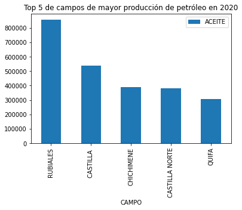

```python
plot = top2020campos.plot(kind='bar', title='Top 5 de campos de mayor producción de petróleo en 2020')
```

# 2

```python
table2018=table_comp[table_comp['YYYY']==2018].reset_index(drop=True)
campo2018cas= table2018[table2018['DEPARTAMENTO']=='CASANARE'].drop('DEPARTAMENTO',axis=1).reset_index()
```

```python
#Se divide en 12 porque en formato largo aparecera 12 veces cada conteo, uno por cada mes
campo2018cascount=(campo2018cas.groupby('OPERADORA')['CAMPO'].count()/12).to_frame()
campo2018cascount=campo2018cascount[campo2018cascount['CAMPO']>=5].sort_values(['CAMPO'],ascending=False)
campo2018cascount
```

| OPERADORA | CAMPO |
| --- | --- |
| Frontera Energy Colombia Corp Sucursal Colombia | 37.0 |
| PERENCO COLOMBIA LIMITED | 36.0 |
| GEOPARK COLOMBIA S.A.S. | 22.0 |
| ECOPETROL S.A. | 10.0 |
| PAREX RESOURCES COLOMBIA LTD. SUCURSAL | 7.0 |
| CEPSA COLOMBIA S.A. | 6.0 |
| COLOMBIA ENERGY DEVELOPMENT CO | 6.0 |
| NEW GRANADA ENERGY CORPORATION SUCURSAL COLOMBIA | 6.0 |
| CARRAO ENERGY S.A. SUCURSAL COLOMIBA | 5.0 |
| LEWIS ENERGY COLOMBIA INC | 5.0 |

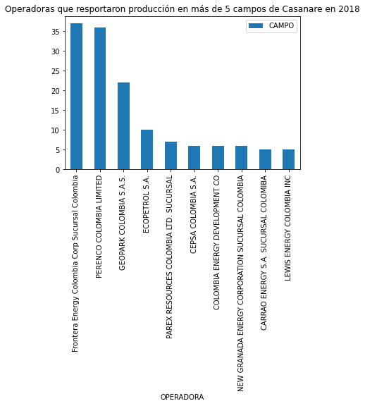

```python
plot = campo2018cascount.plot(kind='bar', title='Operadoras que resportaron producción en más de 5 campos de Casanare en 2018')
```

# 3

```python
contrato2018 = pd.pivot_table(table2018, values='ACEITE', index=['CONTRATO'], aggfunc=np.sum).sort_values(by='ACEITE', ascending=False, na_position='first')
#Divide en 1millon para dejar las unidades en MMstb
top2018contratos=contrato2018[0:5]/1000000
```

```python
top2018contratos
```

| CONTRATO | ACEITE |
| --- | --- |
| CUBARRAL | 2.177189 |
| RUBIALES | 1.433612 |
| LLA 34 | 0.725580 |
| QUIFA | 0.554438 |
| LA CIRA INFANTAS | 0.542415 |

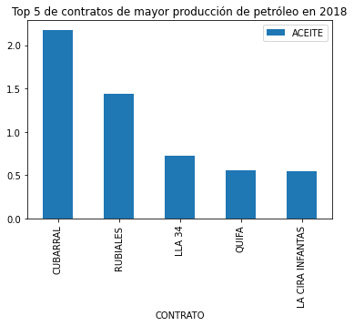

```python
plot = top2018contratos.plot(kind='bar', title='Top 5 de contratos de mayor producción de petróleo en 2018')
```

# 4

```python
table2019=table_comp[table_comp['YYYY']==2019].reset_index(drop=True)
operadora2019 = pd.pivot_table(table2019, values='ACEITE', index=['OPERADORA','MES'], aggfunc=np.sum).sort_values(by='ACEITE', ascending=False, na_position='first').reset_index(level='MES')
operadora2019ago=operadora2019[operadora2019['MES']=='AGOSTO'].sort_values(by='ACEITE', ascending=False, na_position='first').drop('MES',axis=1)
topoperadora2019ago=operadora2019ago[0:10]
```

```python
operadora2019
```

| OPERADORA | MES | ACEITE |
| --- | --- | --- |
| ECOPETROL S.A. | DICIEMBRE | 484942.87 |
| ECOPETROL S.A. | ENERO | 481671.46 |
| ECOPETROL S.A. | JUNIO | 481050.47 |
| ECOPETROL S.A. | FEBRERO | 480734.78 |
| ECOPETROL S.A. | MAYO | 478635.43 |
| ... | ... | ... |
| INVEPETROL LIMITED COLOMBIA | ABRIL | 0.00 |
| TPL COLOMBIA LTD - SUCURSAL COLOMBIA ANTES PANATLANTIC COLOMBIA LTD SUCURSAL EN COLOMBIA | FEBRERO | 0.00 |
| PETROLEOS COLOMBIANOS SA | MARZO | 0.00 |
| PETROLEOS COLOMBIANOS SA | FEBRERO | 0.00 |
| TPL COLOMBIA LTD - SUCURSAL COLOMBIA ANTES PANATLANTIC COLOMBIA LTD SUCURSAL EN COLOMBIA | ENERO | 0.00 |

504 rows × 2 columns

```python
topoperadora2019ago
```

| OPERADORA | ACEITE |
| --- | --- |
| ECOPETROL S.A. | 473986.41 |
| Frontera Energy Colombia Corp Sucursal Colombia | 81441.68 |
| GEOPARK COLOMBIA S.A.S. | 69154.42 |
| OCCIDENTAL DE COLOMBIA LLC | 53299.12 |
| EQUION ENERGÍA LIMITED | 34950.01 |
| GRAN TIERRA ENERGY COLOMBIA LTD | 29555.20 |
| MANSAROVAR ENERGY COLOMBIA LTD | 25256.75 |
| HOCOL S.A. | 19614.02 |
| PAREX RESOURCES COLOMBIA LTD. SUCURSAL | 15727.97 |
| CEPSA COLOMBIA S.A. | 12702.09 |

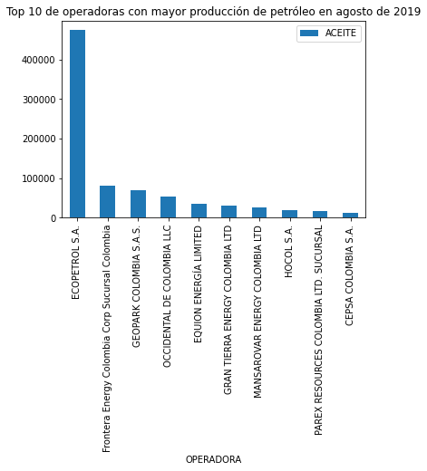

```python
plot = topoperadora2019ago.plot(kind='bar', title='Top 10 de operadoras con mayor producción de petróleo en agosto de 2019')
```

# 5

```python
#Lista para realizar el filtro
T1=['enero','febrero','marzo']
T2=['abril','mayo','junio']
```

```python
#Agrupo por mes
meses2019 = pd.pivot_table(table2019, values='ACEITE', index=['MES'], aggfunc=np.sum).sort_values(by='ACEITE', ascending=False, na_position='first').reset_index(level='MES')
#Aplico formato al texto para realizar el filtro correctamente
meses2019['MES']=meses2019['MES'].apply(lambda x: x.lower())
#Aplico los filtros de los trimestres y guardo los resultados
T12019=meses2019[meses2019['MES'].isin(T1)].reset_index(drop=True)
T22019=meses2019[meses2019['MES'].isin(T2)].reset_index(drop=True)
#Agrupo por mes
meses2020 = pd.pivot_table(table2020, values='ACEITE', index=['MES'], aggfunc=np.sum).sort_values(by='ACEITE', ascending=False, na_position='first').reset_index(level='MES')
#Aplico formato al texto para realizar el filtro correctamente
meses2020['MES']=meses2020['MES'].apply(lambda x: x.lower())
#Aplico los filtros de los trimestres y guardo los resultados
T12020=meses2020[meses2020['MES'].isin(T1)].reset_index(drop=True)
T22020=meses2020[meses2020['MES'].isin(T2)].reset_index(drop=True)
```

```python
#Genero un data frame para guardas los resultados de los filtros y agrupaciones
trim1920 = pd.DataFrame({"Año": [2019,2020], "Trimestre 1": [T12019['ACEITE'].sum(),T12020['ACEITE'].sum()], "Trimestre 2": [T22019['ACEITE'].sum(),T22020['ACEITE'].sum()]})
#Subo a indice la columna año
trim1920.set_index("Año")
```

| Año | Trimestre 1 | Trimestre 2 |
| --- | --- | --- |
| 2019 | 2676538.43 | 2.677717e+06 |
| 2020 | 2619416.71 | 2.258345e+06 |

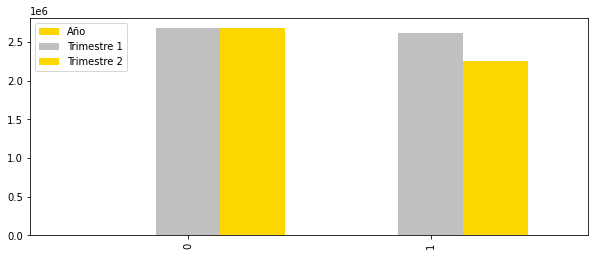

```python
coloresMedallas = ['#FFD700','#C0C0C0']

trim1920.plot(kind = 'bar',
             width=0.8,
             figsize=(10,4),
             color = coloresMedallas);
```

Se describe el procedimiento para las repuestas del reto en lo concerniente al Blind Test. se ajusta la columna con la fecha dado que al trabajarla se tiene como formato 'string' y no como un objecto fecha en python

```python
from pathlib import Path
from datetime import date , datetime
import pandas as pd
import numpy as np
import matplotlib.pyplot as plt
import seaborn as sns
import warnings
from scipy.optimize import curve_fit
from sqlalchemy import create_engine, text
warnings.filterwarnings("ignore")
```

```python
#Creando la conexión con las bases de datos postgres local Nota: postgres deja en minuscula los encabezados, por eso toca pasarlos a mayuscula de nuevo aunque esto ya se hiciera en el archivo de lectura
#engine=create_engine(f'postgresql://postgres:postgres@localhost:5432/HACKATON', max_overflow=20)
#blind_table_comp = pd.read_sql_table('datosciegos',engine)
#blind_table_comp.columns = blind_table_comp.columns.str.upper()
#Si quiere probar los resultados con postgres, descomente las dos lineas anteriores y deje como comentario la siguiente
blind_table_comp = pd.read_csv('Datos/Tablas resumen/Tabla general datos ciegos.csv')
#Aunque en el documento de lectura se asignó a esta columna un tipo de dato datetime, al descargarlo a csv y leer el csv, esto no se conservó y toca cambiar el formato de string a date time
blind_table_comp['FECHA'] = pd.to_datetime(blind_table_comp['FECHA'])
```

```python
blind_table_comp
```

|  | DEPARTAMENTO | MUNICIPIO | OPERADORA | CONTRATO | CAMPO | MES | ACEITE | YYYY | FECHA |
| --- | --- | --- | --- | --- | --- | --- | --- | --- | --- |
| 0 | cf33cb8a | cf33cb8a | d5580f74 | 76a16657 | 1f d2689f | ENERO | 12371.083713 | 2017 | 2017-01-01 |
| 1 | cf33cb8a | cf33cb8a | d5580f74 | 76a16657 | 9ac1420f | ENERO | 5.367156 | 2017 | 2017-01-01 |
| 2 | cf33cb8a | cf33cb8a | d5580f74 | 76a16657 | 9b395bc9 | ENERO | 120.462831 | 2017 | 2017-01-01 |
| 3 | cf33cb8a | cf33cb8a | d5580f74 | 29ded6f4 | 2f614c0b | ENERO | 23208.879752 | 2017 | 2017-01-01 |
| 4 | cf33cb8a | cf33cb8a | d5580f74 | 29ded6f4 | 043b305e | ENERO | 4386.088856 | 2017 | 2017-01-01 |
| ... | ... | ... | ... | ... | ... | ... | ... | ... | ... |
| 1459 | 0fa93c9b | 756c486f | 2fe52430 | 4b05ae15 | 373ebdec | DICIEMBRE | 1084.287554 | 2019 | 2019-12-01 |
| 1460 | 0fa93c9b | 756c486f | 2fe52430 | 4b05ae15 | e32e23a1 | DICIEMBRE | 414.497377 | 2019 | 2019-12-01 |
| 1461 | 657b6154 | a6b36c07 | ffd6d24d | 38c31ea1 | 11e586b4 | DICIEMBRE | 0.000000 | 2019 | 2019-12-01 |
| 1462 | 657b6154 | a6b36c07 | ffd6d24d | 38c31ea1 | 11e586b4 | DICIEMBRE | 408.016097 | 2019 | 2019-12-01 |
| 1463 | 657b6154 | 28b6a6a0 | ffd6d24d | 8568d01e | 8568d01e | DICIEMBRE | 166.892938 | 2019 | 2019-12-01 |

1464 rows × 9 columns

# 6

```python
blind_table2019=blind_table_comp[blind_table_comp['YYYY']==2019].reset_index(drop=True)
#Si se desea inspeccionar otro campo y otro mes, solo debe cambiar estas variables
campo='1f d2689f'
mes='JULIO'
campo2019_7 = blind_table2019[blind_table2019['CAMPO']==campo.lower()][blind_table2019['MES']==mes.upper()].reset_index(drop=True)
print('Caudal de producción del campo', campo.upper(), 'en Julio de 2019:',campo2019_7['ACEITE'][0])
```

```
Caudal de producción del campo 1F D2689F en Julio de 2019: 4766.241346484784
```

```python
blind_table2019
```

|  | DEPARTAMENTO | MUNICIPIO | OPERADORA | CONTRATO | CAMPO | MES | ACEITE | YYYY | FECHA |
| --- | --- | --- | --- | --- | --- | --- | --- | --- | --- |
| 0 | cf33cb8a | cf33cb8a | d5580f74 | 1f d2689f | 1f d2689f | ENERO | 7897.993261 | 2019 | 2019-01-01 |
| 1 | cf33cb8a | cf33cb8a | d5580f74 | 1f d2689f | 9ac1420f | ENERO | 134.214677 | 2019 | 2019-01-01 |
| 2 | cf33cb8a | cf33cb8a | d5580f74 | 1f d2689f | 9b395bc9 | ENERO | 322.628507 | 2019 | 2019-01-01 |
| 3 | cf33cb8a | cf33cb8a | d5580f74 | 1f d2689f | 254d7db5 | ENERO | 40.170881 | 2019 | 2019-01-01 |
| 4 | cf33cb8a | cf33cb8a | d5580f74 | 29ded6f4 | 2f614c0b | ENERO | 22890.888398 | 2019 | 2019-01-01 |
| ... | ... | ... | ... | ... | ... | ... | ... | ... | ... |
| 547 | 0fa93c9b | 756c486f | 2fe52430 | 4b05ae15 | 373ebdec | DICIEMBRE | 1084.287554 | 2019 | 2019-12-01 |
| 548 | 0fa93c9b | 756c486f | 2fe52430 | 4b05ae15 | e32e23a1 | DICIEMBRE | 414.497377 | 2019 | 2019-12-01 |
| 549 | 657b6154 | a6b36c07 | ffd6d24d | 38c31ea1 | 11e586b4 | DICIEMBRE | 0.000000 | 2019 | 2019-12-01 |
| 550 | 657b6154 | a6b36c07 | ffd6d24d | 38c31ea1 | 11e586b4 | DICIEMBRE | 408.016097 | 2019 | 2019-12-01 |
| 551 | 657b6154 | 28b6a6a0 | ffd6d24d | 8568d01e | 8568d01e | DICIEMBRE | 166.892938 | 2019 | 2019-12-01 |

552 rows × 9 columns

```python
blind_table2019[blind_table2019['CAMPO']==campo.lower()]
```

|  | DEPARTAMENTO | MUNICIPIO | OPERADORA | CONTRATO | CAMPO | MES | ACEITE | YYYY | FECHA |
| --- | --- | --- | --- | --- | --- | --- | --- | --- | --- |
| 0 | cf33cb8a | cf33cb8a | d5580f74 | 1f d2689f | 1f d2689f | ENERO | 7897.993261 | 2019 | 2019-01-01 |
| 46 | cf33cb8a | cf33cb8a | d5580f74 | 1f d2689f | 1f d2689f | FEBRERO | 6687.201142 | 2019 | 2019-02-01 |
| 92 | cf33cb8a | cf33cb8a | d5580f74 | 1f d2689f | 1f d2689f | MARZO | 6176.648164 | 2019 | 2019-03-01 |
| 138 | cf33cb8a | cf33cb8a | d5580f74 | 1f d2689f | 1f d2689f | ABRIL | 5998.336864 | 2019 | 2019-04-01 |
| 184 | cf33cb8a | cf33cb8a | d5580f74 | 1f d2689f | 1f d2689f | MAYO | 5838.969170 | 2019 | 2019-05-01 |
| 230 | cf33cb8a | cf33cb8a | d5580f74 | 1f d2689f | 1f d2689f | JUNIO | 6390.660871 | 2019 | 2019-06-01 |
| 276 | cf33cb8a | cf33cb8a | d5580f74 | 1f d2689f | 1f d2689f | JULIO | 4766.241346 | 2019 | 2019-07-01 |
| 322 | cf33cb8a | cf33cb8a | d5580f74 | 1f d2689f | 1f d2689f | AGOSTO | 5871.527810 | 2019 | 2019-08-01 |
| 368 | cf33cb8a | cf33cb8a | d5580f74 | 1f d2689f | 1f d2689f | SEPTIEMBRE | 5179.292397 | 2019 | 2019-09-01 |
| 414 | cf33cb8a | cf33cb8a | d5580f74 | 1f d2689f | 1f d2689f | OCTUBRE | 5928.184630 | 2019 | 2019-10-01 |
| 460 | cf33cb8a | cf33cb8a | d5580f74 | 1f d2689f | 1f d2689f | NOVIEMBRE | 6237.904951 | 2019 | 2019-11-01 |
| 506 | cf33cb8a | cf33cb8a | d5580f74 | 1f d2689f | 1f d2689f | DICIEMBRE | 6226.606211 | 2019 | 2019-12-01 |

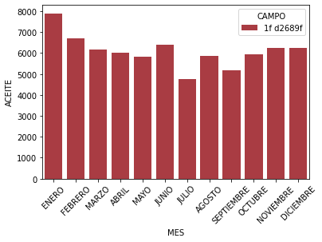

```python
by_field=sns.barplot(x='MES', y='ACEITE', hue='CAMPO', data=blind_table2019[blind_table2019['CAMPO']==campo.lower()], palette=sns.color_palette("RdBu", n_colors=7))
for item in by_field.get_xticklabels():
    item.set_rotation(45)
```

# 7

```python
#Si se desea inspeccionar otro campo y otro mes, solo debe cambiar estas variables
operadora = '2fe52430'
mes = 'FEBRERO'
operadora2019_2 = blind_table2019[blind_table2019['OPERADORA']==operadora.lower()][blind_table2019['MES']==mes.upper()].reset_index(drop=True)
print('Caudal de producción de la operadora', operadora.upper(), 'en Febrero de 2019:',operadora2019_2['ACEITE'].sum())
```

```
Caudal de producción de la operadora 2FE52430 en Febrero de 2019: 7452.2204502174945
```

```python
blind_table2019[blind_table2019['OPERADORA']==operadora.lower()][blind_table2019['MES']==mes.upper()]
```

|  | DEPARTAMENTO | MUNICIPIO | OPERADORA | CONTRATO | CAMPO | MES | ACEITE | YYYY | FECHA |
| --- | --- | --- | --- | --- | --- | --- | --- | --- | --- |
| 74 | f7fd2c4f | 16b873c5 | 2fe52430 | 23980b82 | 7eb34927 | FEBRERO | 88.628230 | 2019 | 2019-02-01 |
| 75 | f7fd2c4f | 16b873c5 | 2fe52430 | 23980b82 | 4f4a249f | FEBRERO | 141.326684 | 2019 | 2019-02-01 |
| 76 | f7fd2c4f | 16b873c5 | 2fe52430 | 23980b82 | 8ba362f3 | FEBRERO | 477.124368 | 2019 | 2019-02-01 |
| 86 | 0fa93c9b | 756c486f | 2fe52430 | 4b05ae15 | 48670499 | FEBRERO | 5605.229884 | 2019 | 2019-02-01 |
| 87 | 0fa93c9b | 756c486f | 2fe52430 | 4b05ae15 | 373ebdec | FEBRERO | 572.625364 | 2019 | 2019-02-01 |
| 88 | 0fa93c9b | 756c486f | 2fe52430 | 4b05ae15 | e32e23a1 | FEBRERO | 567.285920 | 2019 | 2019-02-01 |

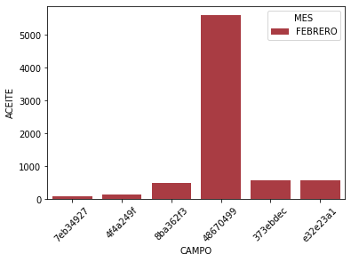

```python
by_field=sns.barplot(x='CAMPO', y='ACEITE', hue='MES', data=blind_table2019[blind_table2019['OPERADORA']==operadora.lower()][blind_table2019['MES']==mes.upper()], palette=sns.color_palette("RdBu", n_colors=7))
for item in by_field.get_xticklabels():
    item.set_rotation(45)
```

# 8

```python
blind_table2018=blind_table_comp[blind_table_comp['YYYY']==2018].reset_index(drop=True)
#Agrupo por departamento
departamento2018 = pd.pivot_table(blind_table2018, values='ACEITE', index=['DEPARTAMENTO'], aggfunc=np.sum).sort_values(by='ACEITE', na_position='first').reset_index()
```

```python
departamento2018
```

|  | DEPARTAMENTO | ACEITE |
| --- | --- | --- |
| 0 | 0fa93c9b | 98767.669386 |
| 1 | f7fd2c4f | 126069.165338 |
| 2 | cf33cb8a | 623608.432526 |

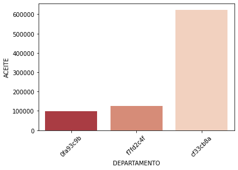

```python
by_field=sns.barplot(x='DEPARTAMENTO', y='ACEITE', data=departamento2018, palette=sns.color_palette("RdBu", n_colors=7))
for item in by_field.get_xticklabels():
    item.set_rotation(45)
```

# 9

```python
depcampo = pd.pivot_table(blind_table_comp, values='ACEITE', index=['DEPARTAMENTO','CAMPO','YYYY'], aggfunc=np.mean).sort_values(by='ACEITE', ascending=False, na_position='first').reset_index()
depcampo.drop(columns=['CAMPO','YYYY'],inplace=True)
```

```python
summary_blind_table=depcampo.groupby('DEPARTAMENTO').describe().unstack(1)
print(summary_blind_table)
```

```
               DEPARTAMENTO
ACEITE  count  0fa93c9b            9.000000
               5f559ecb            1.000000
               657b6154            2.000000
               cf33cb8a           70.000000
               ec12ad00            3.000000
               eccb9ef1            1.000000
               f7fd2c4f           31.000000
        mean   0fa93c9b         2460.323964
               5f559ecb           14.576681
               657b6154          147.434035
               cf33cb8a         1819.576036
               ec12ad00            5.415088
               eccb9ef1           29.290088
               f7fd2c4f         1056.621413
        std    0fa93c9b         2537.313576
               5f559ecb                 NaN
               657b6154           74.044511
               cf33cb8a         2928.122479
               ec12ad00            8.328458
               eccb9ef1                 NaN
               f7fd2c4f         1219.352958
        min    0fa93c9b          479.041021
               5f559ecb           14.576681
               657b6154           95.076659
               cf33cb8a            0.374268
               ec12ad00            0.122720
               eccb9ef1           29.290088
               f7fd2c4f           32.483481
        25%    0fa93c9b          874.141684
               5f559ecb           14.576681
               657b6154          121.255347
               cf33cb8a          132.634932
               ec12ad00            0.615060
               eccb9ef1           29.290088
               f7fd2c4f          317.016578
        50%    0fa93c9b          927.678493
               5f559ecb           14.576681
               657b6154          147.434035
               cf33cb8a          404.799042
               ec12ad00            1.107400
               eccb9ef1           29.290088
               f7fd2c4f          564.751948
        75%    0fa93c9b         5131.886897
               5f559ecb           14.576681
               657b6154          173.612723
               cf33cb8a         2849.668766
               ec12ad00            8.061272
               eccb9ef1           29.290088
               f7fd2c4f         1690.345421
        max    0fa93c9b         6650.664063
               5f559ecb           14.576681
               657b6154          199.791411
               cf33cb8a        12458.858168
               ec12ad00           15.015145
               eccb9ef1           29.290088
               f7fd2c4f         4714.695603
dtype: float64
```

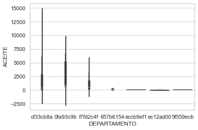

```python
sns.set_theme(style="whitegrid")
ax = sns.violinplot(x="DEPARTAMENTO", y="ACEITE",
                    data=depcampo, palette="muted")
```

Según los valores de desviación estandar, y el "violin plot" se observa claramente que el departamento cf33cb8a es el que tiene mayor variación en la producción promedio anual.

# 10

```python
#Grafica de los datos de producción en el tiempo Nota: Se realiza para que pueda ser graficado distintos campos al tiempo
def RegularPlot(df, wells, units):
    fig, ax = plt.subplots(figsize=(15,8))
    plt.xlabel('Fecha')
    plt.ylabel('ACEITE '+ units)
    for well in wells:
        df_filtered = df[df['CAMPO']==well]
        rate = df_filtered['ACEITE']
        date = df_filtered['FECHA']
        ax.plot(date, rate, 'o', label=well)
    ax.legend(shadow=True, fancybox=True)
    return plt
#Se normaliza la grafica anterior con pasos mensuales

def NormalisedData(df, wells):
    norm_data = {}
    for well in wells:
        df_filtered = df[df['CAMPO']==well]
        start_date = min(df_filtered['FECHA'])
        rate = df_filtered['ACEITE']
        time = df_filtered['FECHA'] - start_date
        time = time.dt.days
        norm_data[well] = {
            'rate': rate,
            'time': time
        }
    return norm_data

def NormalisedPlot(df, wells):
    fig, ax = plt.subplots(figsize=(15, 8))
    plt.xlabel('DIAS')
    plt.ylabel('ACEITE')
    for well in wells:
        df_filtered = df[df['CAMPO']==well]
        start_date = min(df_filtered['FECHA'])
        rate = df_filtered['ACEITE']
        time = df_filtered['FECHA'] - start_date
        time = time.dt.days
        ax.plot(time, rate, 'o', label=well)
    ax.legend(shadow=True, fancybox=True)
    return plt
```

```python
campo = ['51cbb05d']
dfcampo = blind_table_comp.drop(columns=['DEPARTAMENTO','MUNICIPIO','OPERADORA','CONTRATO','YYYY','MES']).reset_index(drop=True)
```

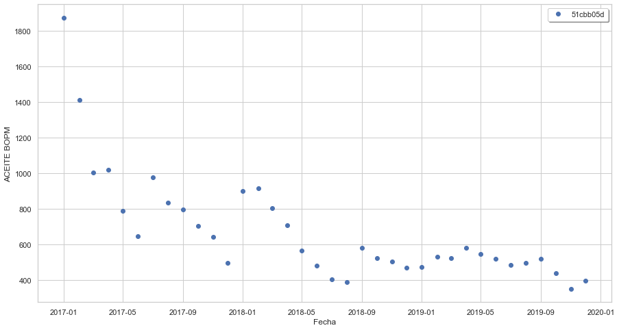

```python
plot_data = RegularPlot (dfcampo, campo, 'BOPM')
```

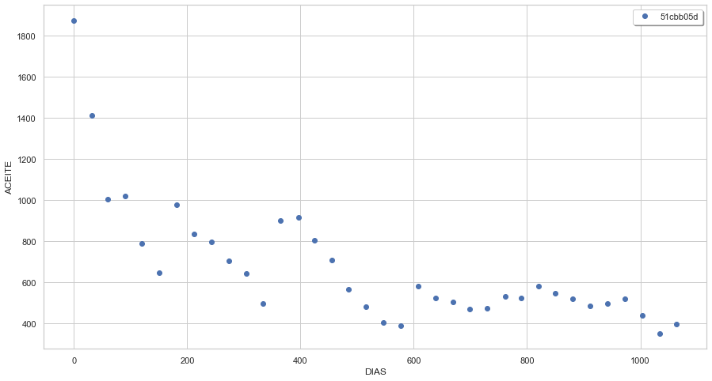

```python
normalised_data = NormalisedData(dfcampo, campo)
normalised_plot = NormalisedPlot(dfcampo, campo)
```

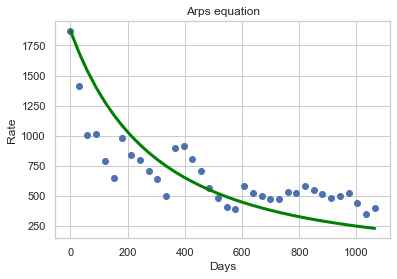

```python
#Se dejará todo expresado de tal manera que si quiere realizar un tiempo de prueba y otro tiempo de testeo de la ecuación, solo deba cambiar "datat" y quitar el númeral de las dos lineas de código comentada
#Esto se hace ya que es algo común en métodos de machine learning
def arps(t, decline):   #Definimos la función de ARPS
        #Declinación hiperbolica
    #Se dejó el b factor como 0.5 según las indicaciones
    values = initialrate / ((1 + 0.5 * decline * t) ** (1 / 0.5))
    return values

fitdict2={}
for well in campo:
    X_p = normalised_data[well]['time']
    Y_p = normalised_data[well]['rate']
    X_arps=X_p[:int(len(X_p))]
    Y_arps=Y_p[:int(len(Y_p))]
    #Como tasa inicial se lee la primera tasa de producción, la cual debido al formato, corresponde al dia 30
    initialrate =  Y_arps[30]
    #Se ajusta la nuve de puntos a la función de la ecuación de Arps
    popt, pcov = curve_fit(arps, X_arps, Y_arps, bounds=([0],[0.1]))
    #Diccionario que guarda las variables que mejor se ajustan a la ecuación de Arps
    fitdict2[well]={

      'decline rate': popt[0]
    }
#Porcentaje de los datos que hubieran sido tomados como entrenamiento
datat=0
time_predict=[]
rate_predict=[]
arps_predict={}
for well in campo:
    X_p = normalised_data[well]['time']
    time_train=X_p[:int(len(X_p)*datat)]
    time_predict=X_p[int(len(X_p)*datat):]    #20% de los datos como prueba
    Y_p = normalised_data[well]['rate']
    rate_test=Y_p[int(len(Y_p)*datat):]
    for time in time_predict:
        rate_predict=arps(time_predict, fitdict2[well]['decline rate'])
        #Descomentar la linea de abajo si quiere realizar split test
        #rate_train=arps(time_train, fitdict[well]['beta'], fitdict[well]['initial rate'], fitdict[well]['decline rate'])
    arps_predict[well]={
        'time':time_predict,
        'rate':rate_predict
    }
    plt.scatter(X_p, Y_p)
    plt.plot(time_predict, rate_predict, color='green', linewidth=3)
    #Descomentar la linea de abajo si quiere realizar split test
    #plt.plot(time_train, rate_train, color='red', linewidth=3)
    plt.xlabel('Days')
    plt.ylabel('Rate')
    plt.title('Arps equation')
    plt.show()
```

```python
print('Se tiene una tasa de declinación de',fitdict2['51cbb05d']['decline rate'])
```

```
Se tiene una tasa de declinación de 0.0034727883551543617
```